# results02_population-accuracy-stats

Tommy Botch

2025-10-02

# Setup environment

## Load packages and setup paths for analysis

Set up directories - since we’re doing this locally (and mounting the server), we’re going to use a different base_dir

# Population-level analysis

## Data loading

Load data and set factors. Our columns are the following: - **modality:** which modality was the stimulus presented as (video, audio, text) - **ground_truth:** ground-truth word to be predicted - **top_pred:** most predicted word across the population - **word_index:** the word index within the story - **task:** which of the three stories was the data from (black, wheretheressmoke, howtodraw)

We create a contrast of modality such that we test the hypothesis that multimodal (video) > spoken (audio) > written (text).

```r
results_fn <- file.path(results_dir, "all-task_group-analyzed-behavior_human-lemmatized.csv")

# Load data and convert columns to factors
df_results <- load_and_prepare_data(
  file_path=results_fn,
  factor_columns=c('modality', 'ground_truth', 'top_pred', 'word_index', 'task', "POS_spaCy", "Clause_Pos", "Clause_ID")
)

# Set the levels for the modality column
df_results <- set_factor_levels(
  df=df_results,
  column_name="modality",
  levels=c("video", "audio", "text")
)

df_results <- create_column_contrast(
  df=df_results,
  column_name="modality"
)

# Drop multiple columns
df_results <- df_results %>% select(-c(prominence, boundary))

colnames(df_results)
```

```
##  [1] "modality"
##  [2] "word_index"
##  [3] "ground_truth"
##  [4] "top_pred"
##  [5] "accuracy"
##  [6] "predictability"
##  [7] "top_prob"
##  [8] "n_predictions"
##  [9] "entropy"
## [10] "normalized_entropy"
## [11] "bert_top_word_accuracy"
## [12] "fasttext_top_word_accuracy"
## [13] "fasttext_avg_accuracy"
## [14] "fasttext_max_accuracy"
## [15] "fasttext_weighted_pred.gt_accuracy"
```

[output cut: 48 more lines]

## Analysis 1A - Population-level binary accuracy

We now aggregate predictions into a distribution across subjects, and find the most commonly predicted word for participants within each condition. We then predicted the binary accuracy (one-shot accuracy) based on the modality of presentation (condition) while controlling for random effects of trial (word_index) within each task (story).

Given that accuracy is a binary measure (0/1), we used a logistic mixed-effects model.

```r
binary_accuracy_formula <- 'accuracy ~ modality + (1|word_index:task)'

# Fit the logistic mixed-effects model
model <- glmer(binary_accuracy_formula,
               data = df_results,
               family = binomial(link = "logit"))

tab_model(model, show.se=TRUE, show.stat=TRUE, show.r2=TRUE, show.df=TRUE)
```

|  | accuracy |  |  |  |  |  |
| --- | --- | --- | --- | --- | --- | --- |
| Predictors | Odds Ratios | std. Error | CI | Statistic | p | df |
| (Intercept) | 0.51 | 0.11 | 0.33 – 0.77 | -3.20 | **0.001** | Inf |
| modality L | 0.23 | 0.04 | 0.17 – 0.31 | -9.56 | **<0.001** | Inf |
| modality Q | 0.70 | 0.09 | 0.54 – 0.91 | -2.65 | **0.008** | Inf |
| Random Effects |  |  |  |  |  |  |
| σ<sup>2</sup> | 3.29 |  |  |  |  |  |
| τ<sub>00</sub> <sub>word_index:task</sub> | 17.14 |  |  |  |  |  |
| ICC | 0.84 |  |  |  |  |  |
| N <sub>word_index</sub> | 594 |  |  |  |  |  |
| N <sub>task</sub> | 3 |  |  |  |  |  |
| Observations | 2016 |  |  |  |  |  |
| Marginal R<sup>2</sup> / Conditional R<sup>2</sup> | 0.037 / 0.845 |  |  |  |  |  |

```r
# Display results of fixed effects
display_model_summary(model)
```

Model Fixed Effects Summary

| Predictor | Fixed Effects Results Coefficient Estimate | Fixed Effects Results Standard Error | Fixed Effects Results Z-Statistic | Fixed Effects Results P-Value |
| --- | --- | --- | --- | --- |
| (Intercept) | -0.6782907 | 0.2121868 | -3.196668 | 1.390250e-03 |
| modality.L | -1.4912742 | 0.1560607 | -9.555734 | 1.227104e-21 |
| modality.Q | -0.3543554 | 0.1339381 | -2.645665 | 8.153047e-03 |

```r
# Conduct pairwise comparisons between modalities
pairwise_comparisons <- emmeans(model, pairwise ~ modality)
display_pairwise_comparisons(pairwise_comparisons)
```

Pairwise Comparisons

| Comparison Results Comparison | Comparison Results Difference in Mean | Comparison Results Standard Error | Comparison Results Degrees of Freedom | Comparison Results Z-Statistic | Comparison Results P-Value |
| --- | --- | --- | --- | --- | --- |
| video - audio | 0.6204952 | 0.1882976 | Inf | 3.295289 | 2.826522e-03 |
| video - text | 2.1089802 | 0.2207031 | Inf | 9.555734 | 2.386980e-14 |
| audio - text | 1.4884851 | 0.2066814 | Inf | 7.201835 | 1.804223e-12 |

### Analysis 1B - Prosody interaction with binary accuracy

We can also look at whether the average prosody (prominence) leading up to a to-be-predicted word exhibits an interaction with modality. We therefore run an additional model investigating whether the two are related.

```r
binary_accuracy_formula <- 'accuracy ~ modality * prominence_mean_words5 + (1|word_index:task)'

# Fit the logistic mixed-effects model
model <- glmer(binary_accuracy_formula,
               data = df_results,
               family = binomial(link = "logit"))

tab_model(model, show.se=TRUE, show.stat=TRUE, show.r2=TRUE, show.df=TRUE)
```

|  | accuracy |  |  |  |  |  |
| --- | --- | --- | --- | --- | --- | --- |
| Predictors | Odds Ratios | std. Error | CI | Statistic | p | df |
| (Intercept) | 0.37 | 0.16 | 0.16 – 0.85 | -2.34 | **0.019** | Inf |
| modality L | 0.57 | 0.17 | 0.33 – 1.01 | -1.92 | 0.054 | Inf |
| modality Q | 0.90 | 0.24 | 0.53 – 1.52 | -0.41 | 0.683 | Inf |
| prominence mean words5 | 1.79 | 1.28 | 0.44 – 7.26 | 0.82 | 0.412 | Inf |
| modality L × prominence mean words5 | 0.13 | 0.07 | 0.04 – 0.40 | -3.59 | **<0.001** | Inf |
| modality Q × prominence mean words5 | 0.59 | 0.29 | 0.23 – 1.53 | -1.08 | 0.278 | Inf |
| Random Effects |  |  |  |  |  |  |
| σ<sup>2</sup> | 3.29 |  |  |  |  |  |
| τ<sub>00</sub> <sub>word_index:task</sub> | 18.04 |  |  |  |  |  |
| ICC | 0.85 |  |  |  |  |  |
| N <sub>word_index</sub> | 594 |  |  |  |  |  |
| N <sub>task</sub> | 3 |  |  |  |  |  |
| Observations | 2016 |  |  |  |  |  |
| Marginal R<sup>2</sup> / Conditional R<sup>2</sup> | 0.044 / 0.853 |  |  |  |  |  |

```r
# Display results of fixed effects
display_model_summary(model)
```

Model Fixed Effects Summary

| Predictor | Fixed Effects Results Coefficient Estimate | Fixed Effects Results Standard Error | Fixed Effects Results Z-Statistic | Fixed Effects Results P-Value |
| --- | --- | --- | --- | --- |
| (Intercept) | -0.9830909 | 0.4192489 | -2.3448860 | 0.0190328966 |
| modality.L | -0.5556094 | 0.2888804 | -1.9233200 | 0.0544398704 |
| modality.Q | -0.1092669 | 0.2677153 | -0.4081460 | 0.6831664630 |
| prominence_mean_words5 | 0.5848984 | 0.7132624 | 0.8200325 | 0.4121975687 |
| modality.L:prominence_mean_words5 | -2.0205800 | 0.5629911 | -3.5890087 | 0.0003319378 |
| modality.Q:prominence_mean_words5 | -0.5294709 | 0.4884098 | -1.0840710 | 0.2783333228 |

```r
# Conduct pairwise comparisons between modalities
pairwise_comparisons <- emmeans(model, pairwise ~ modality)
```

```
## NOTE: Results may be misleading due to involvement in interactions
```

```r
display_pairwise_comparisons(pairwise_comparisons)
```

Pairwise Comparisons

| Comparison Results Comparison | Comparison Results Difference in Mean | Comparison Results Standard Error | Comparison Results Degrees of Freedom | Comparison Results Z-Statistic | Comparison Results P-Value |
| --- | --- | --- | --- | --- | --- |
| video - audio | 0.6360017 | 0.1905851 | Inf | 3.337101 | 2.439411e-03 |
| video - text | 2.1661805 | 0.2284601 | Inf | 9.481658 | 2.597922e-14 |
| audio - text | 1.5301788 | 0.2130541 | Inf | 7.182112 | 2.080780e-12 |

### Plot interaction model

```
## Data were 'prettified'. Consider using `terms="prominence_mean_words5
##   [all]"` to get smooth plots.
```

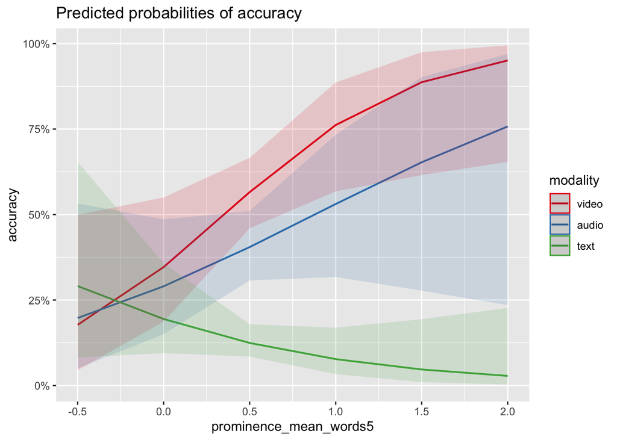

```r
plot_model(model, type="pred", terms=c("prominence_mean_words5", "modality"))
```

## Analysis 1C - Task-level comparisons (binary accuracy)

```r
binary_accuracy_formula <- 'accuracy ~ modality + (1|word_index)'
```

#### Story = Black

```r
model <- lmer_task(
  task_name='black',
  df=df_results,
  formula=binary_accuracy_formula,
  family=binomial(link="logit")
)

# Output the results
tab_model(model, show.se = TRUE, show.stat = TRUE, show.r2 = TRUE)
```

|  | Dependent variable |  |  |  |  |
| --- | --- | --- | --- | --- | --- |
| Predictors | Odds Ratios | std. Error | CI | Statistic | p |
| (Intercept) | 1.08 | 0.41 | 0.51 – 2.28 | 0.20 | 0.841 |
| modality L | 0.12 | 0.04 | 0.06 – 0.24 | -6.04 | **<0.001** |
| modality Q | 0.45 | 0.12 | 0.27 – 0.77 | -2.92 | **0.004** |
| Random Effects |  |  |  |  |  |
| σ<sup>2</sup> | 3.29 |  |  |  |  |
| τ<sub>00</sub> <sub>word_index</sub> | 18.15 |  |  |  |  |
| ICC | 0.85 |  |  |  |  |
| N <sub>word_index</sub> | 194 |  |  |  |  |
| Observations | 582 |  |  |  |  |
| Marginal R<sup>2</sup> / Conditional R<sup>2</sup> | 0.072 / 0.858 |  |  |  |  |

```r
# Display results of fixed effects
display_model_summary(model)
```

Model Fixed Effects Summary

| Predictor | Fixed Effects Results Coefficient Estimate | Fixed Effects Results Standard Error | Fixed Effects Results Z-Statistic | Fixed Effects Results P-Value |
| --- | --- | --- | --- | --- |
| (Intercept) | 0.07675634 | 0.3815813 | 0.2011533 | 8.405787e-01 |
| modality.L | -2.09070792 | 0.3461486 | -6.0399139 | 1.541965e-09 |
| modality.Q | -0.78796826 | 0.2701112 | -2.9172001 | 3.531892e-03 |

```r
# Conduct pairwise comparisons between modalities
pairwise_comparisons <- emmeans(model, pairwise ~ modality)
display_pairwise_comparisons(pairwise_comparisons)
```

Pairwise Comparisons

| Comparison Results Comparison | Comparison Results Difference in Mean | Comparison Results Standard Error | Comparison Results Degrees of Freedom | Comparison Results Z-Statistic | Comparison Results P-Value |
| --- | --- | --- | --- | --- | --- |
| video - audio | 0.5132937 | 0.3617007 | Inf | 1.419112 | 3.309780e-01 |
| video - text | 2.9567075 | 0.4895281 | Inf | 6.039914 | 4.624240e-09 |
| audio - text | 2.4434138 | 0.4559294 | Inf | 5.359194 | 2.504162e-07 |

#### Story = Smoke

```r
model <- lmer_task(
  task_name='wheretheressmoke',
  df=df_results,
  formula=binary_accuracy_formula,
  family=binomial(link="logit")
)

# Output the results
tab_model(model, show.se = TRUE, show.stat = TRUE, show.r2 = TRUE)
```

|  | Dependent variable |  |  |  |  |
| --- | --- | --- | --- | --- | --- |
| Predictors | Odds Ratios | std. Error | CI | Statistic | p |
| (Intercept) | 0.40 | 0.14 | 0.20 – 0.81 | -2.53 | **0.011** |
| modality L | 0.21 | 0.06 | 0.13 – 0.36 | -5.87 | **<0.001** |
| modality Q | 1.14 | 0.25 | 0.73 – 1.76 | 0.58 | 0.565 |
| Random Effects |  |  |  |  |  |
| σ<sup>2</sup> | 3.29 |  |  |  |  |
| τ<sub>00</sub> <sub>word_index</sub> | 16.53 |  |  |  |  |
| ICC | 0.83 |  |  |  |  |
| N <sub>word_index</sub> | 237 |  |  |  |  |
| Observations | 711 |  |  |  |  |
| Marginal R<sup>2</sup> / Conditional R<sup>2</sup> | 0.039 / 0.840 |  |  |  |  |

```r
# Display results of fixed effects
display_model_summary(model)
```

Model Fixed Effects Summary

| Predictor | Fixed Effects Results Coefficient Estimate | Fixed Effects Results Standard Error | Fixed Effects Results Z-Statistic | Fixed Effects Results P-Value |
| --- | --- | --- | --- | --- |
| (Intercept) | -0.9122286 | 0.3600815 | -2.5333946 | 1.129637e-02 |
| modality.L | -1.5441851 | 0.2631022 | -5.8691457 | 4.380464e-09 |
| modality.Q | 0.1285581 | 0.2235012 | 0.5752008 | 5.651555e-01 |

```r
# Conduct pairwise comparisons between modalities
pairwise_comparisons <- emmeans(model, pairwise ~ modality)
display_pairwise_comparisons(pairwise_comparisons)
```

Pairwise Comparisons

| Comparison Results Comparison | Comparison Results Difference in Mean | Comparison Results Standard Error | Comparison Results Degrees of Freedom | Comparison Results Z-Statistic | Comparison Results P-Value |
| --- | --- | --- | --- | --- | --- |
| video - audio | 1.2493546 | 0.3293415 | Inf | 3.793493 | 4.363031e-04 |
| video - text | 2.1838076 | 0.3720827 | Inf | 5.869146 | 1.313456e-08 |
| audio - text | 0.9344529 | 0.3325888 | Inf | 2.809634 | 1.374612e-02 |

#### Story = Draw

```r
model <- lmer_task(
  task_name='howtodraw',
  df=df_results,
  formula=binary_accuracy_formula,
  family=binomial(link="logit")
)

# Output the results
tab_model(model, show.se = TRUE, show.stat = TRUE, show.r2 = TRUE)
```

|  | Dependent variable |  |  |  |  |
| --- | --- | --- | --- | --- | --- |
| Predictors | Odds Ratios | std. Error | CI | Statistic | p |
| (Intercept) | 0.32 | 0.13 | 0.14 – 0.72 | -2.75 | **0.006** |
| modality L | 0.35 | 0.09 | 0.22 – 0.57 | -4.21 | **<0.001** |
| modality Q | 0.59 | 0.14 | 0.38 – 0.93 | -2.27 | **0.023** |
| Random Effects |  |  |  |  |  |
| σ<sup>2</sup> | 3.29 |  |  |  |  |
| τ<sub>00</sub> <sub>word_index</sub> | 19.71 |  |  |  |  |
| ICC | 0.86 |  |  |  |  |
| N <sub>word_index</sub> | 241 |  |  |  |  |
| Observations | 723 |  |  |  |  |
| Marginal R<sup>2</sup> / Conditional R<sup>2</sup> | 0.020 / 0.860 |  |  |  |  |

```r
# Display results of fixed effects
display_model_summary(model)
```

Model Fixed Effects Summary

| Predictor | Fixed Effects Results Coefficient Estimate | Fixed Effects Results Standard Error | Fixed Effects Results Z-Statistic | Fixed Effects Results P-Value |
| --- | --- | --- | --- | --- |
| (Intercept) | -1.1443712 | 0.4165983 | -2.746942 | 6.015384e-03 |
| modality.L | -1.0478187 | 0.2485934 | -4.214990 | 2.497898e-05 |
| modality.Q | -0.5235376 | 0.2303401 | -2.272890 | 2.303282e-02 |

```r
# Conduct pairwise comparisons between modalities
pairwise_comparisons <- emmeans(model, pairwise ~ modality)
display_pairwise_comparisons(pairwise_comparisons)
```

Pairwise Comparisons

| Comparison Results Comparison | Comparison Results Difference in Mean | Comparison Results Standard Error | Comparison Results Degrees of Freedom | Comparison Results Z-Statistic | Comparison Results P-Value |
| --- | --- | --- | --- | --- | --- |
| video - audio | 0.09971965 | 0.3150961 | Inf | 0.3164738 | 9.462892e-01 |
| video - text | 1.48183937 | 0.3515642 | Inf | 4.2149895 | 7.411213e-05 |
| audio - text | 1.38211972 | 0.3488306 | Inf | 3.9621512 | 2.192030e-04 |

## Analysis 2A - Population-level continuous accuracy

We next evaluate the semantic similarity of human predictions to the ground-truth word. We use fasttext as a semantic embedding space and calculate the cosine similarity between each prediction and the ground-truth word. This turns accuracy into a continuous metric (now referred to as “continuous accuracy”).

We use a linear mixed-effects model to predict continous accuracy based on the modality of presentation (condition) while controlling for random effects of trial (word_index) within each task (story).

```r
continuous_accuracy_formula <- 'fasttext_top_word_accuracy ~ modality + (1|word_index:task)'

# Fit the logistic mixed-effects model
model <- lmer(continuous_accuracy_formula, data=df_results)

tab_model(model, show.se=TRUE, show.stat=TRUE, show.r2=TRUE, show.df=TRUE)
```

|  | fasttext_top_word_accuracy |  |  |  |  |  |
| --- | --- | --- | --- | --- | --- | --- |
| Predictors | Estimates | std. Error | CI | Statistic | p | df |
| (Intercept) | 0.61 | 0.01 | 0.59 – 0.64 | 47.70 | **<0.001** | 2011.00 |
| modality L | -0.09 | 0.01 | -0.10 – -0.07 | -11.08 | **<0.001** | 2011.00 |
| modality Q | -0.02 | 0.01 | -0.03 – -0.00 | -2.14 | **0.032** | 2011.00 |
| Random Effects |  |  |  |  |  |  |
| σ<sup>2</sup> | 0.04 |  |  |  |  |  |
| τ<sub>00</sub> <sub>word_index:task</sub> | 0.10 |  |  |  |  |  |
| ICC | 0.70 |  |  |  |  |  |
| N <sub>word_index</sub> | 594 |  |  |  |  |  |
| N <sub>task</sub> | 3 |  |  |  |  |  |
| Observations | 2016 |  |  |  |  |  |
| Marginal R<sup>2</sup> / Conditional R<sup>2</sup> | 0.018 / 0.708 |  |  |  |  |  |

```r
AIC(model)
```

```
## [1] 720.7529
```

```r
# Display results of fixed effects
display_model_summary(model)
```

Model Fixed Effects Summary

| Predictor | Fixed Effects Results Coefficient Estimate | Fixed Effects Results Standard Error | Fixed Effects Results T-Statistic | Fixed Effects Results P-Value | df |  |
| --- | --- | --- | --- | --- | --- | --- |
| (Intercept) | 0.61232443 | 0.01283666 | 47.701232 | 9.162455e-218 |  | 671 |
| modality.L | -0.08665988 | 0.00782130 | -11.079984 | 2.313651e-27 | 1342 |  |
| modality.Q | -0.01677202 | 0.00782130 | -2.144404 | 3.217973e-02 | 1342 |  |

```r
# Conduct pairwise comparisons between modalities
pairwise_comparisons <- emmeans(model, pairwise ~ modality)
display_pairwise_comparisons(pairwise_comparisons)
```

Pairwise Comparisons

| Comparison Results Comparison | Comparison Results Difference in Mean | Comparison Results Standard Error | Comparison Results Degrees of Freedom | Comparison Results T-Statistic | Comparison Results P-Value |
| --- | --- | --- | --- | --- | --- |
| video - audio | 0.04073634 | 0.01106099 | 1342 | 3.682884 | 7.010562e-04 |
| video - text | 0.12255557 | 0.01106099 | 1342 | 11.079984 | 1.024736e-13 |
| audio - text | 0.08181924 | 0.01106099 | 1342 | 7.397100 | 8.403278e-13 |

## Analysis 2B - Prosody interaction with continuous accuracy

We also look at how the average prosody leading up to a word informs the semantic similarity of the predictions.

```r
continuous_accuracy_formula <- 'fasttext_top_word_accuracy ~ modality * prominence_mean_words5 + (1|word_index:task)'

# Fit the logistic mixed-effects model
model <- lmer(continuous_accuracy_formula, data=df_results)

tab_model(model, show.se=TRUE, show.stat=TRUE, show.r2=TRUE, show.df=TRUE)
```

|  | fasttext_top_word_accuracy |  |  |  |  |  |
| --- | --- | --- | --- | --- | --- | --- |
| Predictors | Estimates | std. Error | CI | Statistic | p | df |
| (Intercept) | 0.59 | 0.03 | 0.54 – 0.64 | 23.64 | **<0.001** | 2008.00 |
| modality L | -0.04 | 0.02 | -0.07 – -0.01 | -2.53 | **0.012** | 2008.00 |
| modality Q | -0.01 | 0.02 | -0.04 – 0.02 | -0.60 | 0.551 | 2008.00 |
| prominence mean words5 | 0.04 | 0.04 | -0.05 – 0.13 | 0.95 | 0.343 | 2008.00 |
| modality L × prominence mean words5 | -0.10 | 0.03 | -0.15 – -0.05 | -3.70 | **<0.001** | 2008.00 |
| modality Q × prominence mean words5 | -0.02 | 0.03 | -0.07 – 0.04 | -0.59 | 0.554 | 2008.00 |
| Random Effects |  |  |  |  |  |  |
| σ<sup>2</sup> | 0.04 |  |  |  |  |  |
| τ<sub>00</sub> <sub>word_index:task</sub> | 0.10 |  |  |  |  |  |
| ICC | 0.70 |  |  |  |  |  |
| N <sub>word_index</sub> | 594 |  |  |  |  |  |
| N <sub>task</sub> | 3 |  |  |  |  |  |
| Observations | 2016 |  |  |  |  |  |
| Marginal R<sup>2</sup> / Conditional R<sup>2</sup> | 0.022 / 0.711 |  |  |  |  |  |

```r
summary (model)
```

```
## Linear mixed model fit by REML. t-tests use Satterthwaite's method [
## lmerModLmerTest]
## Formula: continuous_accuracy_formula
##    Data: df_results
##
## REML criterion at convergence: 711
##
## Scaled residuals:
##     Min      1Q  Median      3Q     Max
## -3.3167 -0.3999  0.0369  0.4751  3.3742
##
## Random effects:
##  Groups          Name        Variance Std.Dev.
##  word_index:task (Intercept) 0.09717  0.3117
##  Residual                    0.04074  0.2018
## Number of obs: 2016, groups:  word_index:task, 672
##
## Fixed effects:
##                                     Estimate Std. Error         df t value
## (Intercept)                          0.59192    0.02504  669.99996  23.642
## modality.L                          -0.03839    0.01519 1340.00002  -2.528
## modality.Q                          -0.00906    0.01519 1340.00002  -0.597
## prominence_mean_words5               0.04224    0.04450  669.99996   0.949
## modality.L:prominence_mean_words5   -0.09992    0.02699 1340.00002  -3.702
## modality.Q:prominence_mean_words5   -0.01596    0.02699 1340.00002  -0.592
##                                   Pr(>|t|)
## (Intercept)                        < 2e-16 ***
## modality.L                        0.011579 *
## modality.Q                        0.550866
## prominence_mean_words5            0.342836
## modality.L:prominence_mean_words5 0.000222 ***
## modality.Q:prominence_mean_words5 0.554266
## ---
## Signif. codes:  0 '***' 0.001 '**' 0.01 '*' 0.05 '.' 0.1 ' ' 1
##
## Correlation of Fixed Effects:
##             (Intr) mdlt.L mdlt.Q prm__5 m.L:__
## modality.L   0.000
## modality.Q   0.000  0.000
## prmnnc_mn_5 -0.859  0.000  0.000
## mdlty.L:__5  0.000 -0.859  0.000  0.000
## mdlty.Q:__5  0.000  0.000 -0.859  0.000  0.000
```

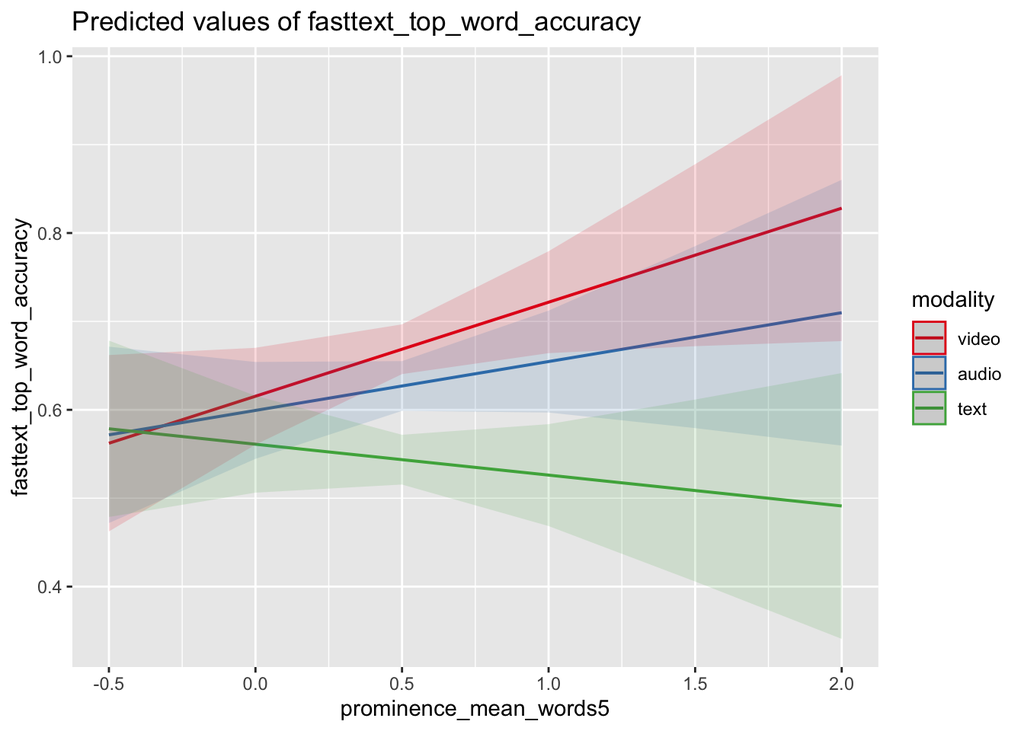

```r
plot_model(model, type='pred', terms=c('prominence_mean_words5', 'modality'))
```

## Analysis 2C - Task-level comparisons (continuous accuracy)

We are also interested in understanding how these effects exist at the level of individual tasks. Since task is a random effect in previous models, we therefore run separate models for each tasks.

We first setup our formula to evaluate our model – we discard task are random-effect as we are inherently testing at the task-level.

```r
continuous_accuracy_formula <- 'fasttext_top_word_accuracy ~ modality + (1|word_index)'
```

#### Story = Black

```r
model <- lmer_task(
  task_name='black',
  df=df_results,
  formula=continuous_accuracy_formula,
)

# Output the results
tab_model(model, show.se=TRUE, show.stat=TRUE, show.r2=TRUE, show.df=TRUE)
```

|  | Dependent variable |  |  |  |  |  |
| --- | --- | --- | --- | --- | --- | --- |
| Predictors | Estimates | std. Error | CI | Statistic | p | df |
| (Intercept) | 0.66 | 0.02 | 0.61 – 0.70 | 28.43 | **<0.001** | 577.00 |
| modality L | -0.11 | 0.02 | -0.14 – -0.08 | -7.22 | **<0.001** | 577.00 |
| modality Q | -0.04 | 0.02 | -0.07 – -0.01 | -2.79 | **0.005** | 577.00 |
| Random Effects |  |  |  |  |  |  |
| σ<sup>2</sup> | 0.05 |  |  |  |  |  |
| τ<sub>00</sub> <sub>word_index</sub> | 0.09 |  |  |  |  |  |
| ICC | 0.66 |  |  |  |  |  |
| N <sub>word_index</sub> | 194 |  |  |  |  |  |
| Observations | 582 |  |  |  |  |  |
| Marginal R<sup>2</sup> / Conditional R<sup>2</sup> | 0.034 / 0.674 |  |  |  |  |  |

```r
# Display results of fixed effects
display_model_summary(model)
```

Model Fixed Effects Summary

| Predictor | Fixed Effects Results Coefficient Estimate | Fixed Effects Results Standard Error | Fixed Effects Results T-Statistic | Fixed Effects Results P-Value | df |  |
| --- | --- | --- | --- | --- | --- | --- |
| (Intercept) | 0.6583131 | 0.02315461 | 28.431189 | 6.383194e-71 |  | 193 |
| modality.L | -0.1103837 | 0.01528446 | -7.221958 | 2.750871e-12 | 386 |  |
| modality.Q | -0.0426765 | 0.01528446 | -2.792150 | 5.496324e-03 | 386 |  |

```r
# Conduct pairwise comparisons between modalities
pairwise_comparisons <- emmeans(model, pairwise ~ modality)
display_pairwise_comparisons(pairwise_comparisons)
```

Pairwise Comparisons

| Comparison Results Comparison | Comparison Results Difference in Mean | Comparison Results Standard Error | Comparison Results Degrees of Freedom | Comparison Results T-Statistic | Comparison Results P-Value |
| --- | --- | --- | --- | --- | --- |
| video - audio | 0.02578526 | 0.02161549 | 386 | 1.192906 | 4.581060e-01 |
| video - text | 0.15610616 | 0.02161549 | 386 | 7.221958 | 0.000000e+00 |
| audio - text | 0.13032090 | 0.02161549 | 386 | 6.029052 | 1.155352e-08 |

#### Story = Smoke

```r
model <- lmer_task(
  task_name='wheretheressmoke',
  df=df_results,
  formula=continuous_accuracy_formula,
)

# Output the results
tab_model(model, show.se=TRUE, show.stat=TRUE, show.r2=TRUE, show.df=TRUE)
```

|  | Dependent variable |  |  |  |  |  |
| --- | --- | --- | --- | --- | --- | --- |
| Predictors | Estimates | std. Error | CI | Statistic | p | df |
| (Intercept) | 0.60 | 0.02 | 0.56 – 0.64 | 27.76 | **<0.001** | 706.00 |
| modality L | -0.09 | 0.01 | -0.12 – -0.07 | -7.08 | **<0.001** | 706.00 |
| modality Q | 0.01 | 0.01 | -0.02 – 0.04 | 0.81 | 0.419 | 706.00 |
| Random Effects |  |  |  |  |  |  |
| σ<sup>2</sup> | 0.04 |  |  |  |  |  |
| τ<sub>00</sub> <sub>word_index</sub> | 0.10 |  |  |  |  |  |
| ICC | 0.70 |  |  |  |  |  |
| N <sub>word_index</sub> | 237 |  |  |  |  |  |
| Observations | 711 |  |  |  |  |  |
| Marginal R<sup>2</sup> / Conditional R<sup>2</sup> | 0.021 / 0.710 |  |  |  |  |  |

```r
# Display results of fixed effects
display_model_summary(model)
```

Model Fixed Effects Summary

| Predictor | Fixed Effects Results Coefficient Estimate | Fixed Effects Results Standard Error | Fixed Effects Results T-Statistic | Fixed Effects Results P-Value | df |  |
| --- | --- | --- | --- | --- | --- | --- |
| (Intercept) | 0.59773364 | 0.02153045 | 27.7622415 | 2.702348e-76 |  | 236 |
| modality.L | -0.09257001 | 0.01307710 | -7.0787879 | 5.297207e-12 | 472 |  |
| modality.Q | 0.01057532 | 0.01307710 | 0.8086902 | 4.191008e-01 | 472 |  |

```r
# Conduct pairwise comparisons between modalities
pairwise_comparisons <- emmeans(model, pairwise ~ modality)
display_pairwise_comparisons(pairwise_comparisons)
```

Pairwise Comparisons

| Comparison Results Comparison | Comparison Results Difference in Mean | Comparison Results Standard Error | Comparison Results Degrees of Freedom | Comparison Results T-Statistic | Comparison Results P-Value |
| --- | --- | --- | --- | --- | --- |
| video - audio | 0.07840895 | 0.01849381 | 472 | 4.239740 | 7.979884e-05 |
| video - text | 0.13091376 | 0.01849381 | 472 | 7.078788 | 4.405187e-11 |
| audio - text | 0.05250481 | 0.01849381 | 472 | 2.839048 | 1.307876e-02 |

#### Story = Draw

```r
model <- lmer_task(
  task_name='howtodraw',
  df=df_results,
  formula=continuous_accuracy_formula,
)

# Output the results
tab_model(model, show.se=TRUE, show.stat=TRUE, show.r2=TRUE, show.df=TRUE)
```

|  | Dependent variable |  |  |  |  |  |
| --- | --- | --- | --- | --- | --- | --- |
| Predictors | Estimates | std. Error | CI | Statistic | p | df |
| (Intercept) | 0.59 | 0.02 | 0.55 – 0.63 | 26.94 | **<0.001** | 718.00 |
| modality L | -0.06 | 0.01 | -0.09 – -0.04 | -4.96 | **<0.001** | 718.00 |
| modality Q | -0.02 | 0.01 | -0.05 – 0.00 | -1.83 | 0.068 | 718.00 |
| Random Effects |  |  |  |  |  |  |
| σ<sup>2</sup> | 0.04 |  |  |  |  |  |
| τ<sub>00</sub> <sub>word_index</sub> | 0.10 |  |  |  |  |  |
| ICC | 0.73 |  |  |  |  |  |
| N <sub>word_index</sub> | 241 |  |  |  |  |  |
| Observations | 723 |  |  |  |  |  |
| Marginal R<sup>2</sup> / Conditional R<sup>2</sup> | 0.010 / 0.736 |  |  |  |  |  |

```r
# Display results of fixed effects
display_model_summary(model)
```

Model Fixed Effects Summary

| Predictor | Fixed Effects Results Coefficient Estimate | Fixed Effects Results Standard Error | Fixed Effects Results T-Statistic | Fixed Effects Results P-Value | df |  |
| --- | --- | --- | --- | --- | --- | --- |
| (Intercept) | 0.58965308 | 0.02188976 | 26.937398 | 1.664385e-74 |  | 240 |
| modality.L | -0.06175063 | 0.01246013 | -4.955856 | 1.000082e-06 | 480 |  |
| modality.Q | -0.02281291 | 0.01246013 | -1.830872 | 6.773946e-02 | 480 |  |

```r
# Conduct pairwise comparisons between modalities
pairwise_comparisons <- emmeans(model, pairwise ~ modality)
display_pairwise_comparisons(pairwise_comparisons)
```

Pairwise Comparisons

| Comparison Results Comparison | Comparison Results Difference in Mean | Comparison Results Standard Error | Comparison Results Degrees of Freedom | Comparison Results T-Statistic | Comparison Results P-Value |
| --- | --- | --- | --- | --- | --- |
| video - audio | 0.01572430 | 0.01762129 | 480 | 0.8923468 | 6.454027e-01 |
| video - text | 0.08732858 | 0.01762129 | 480 | 4.9558563 | 2.988084e-06 |
| audio - text | 0.07160428 | 0.01762129 | 480 | 4.0635095 | 1.667106e-04 |

## Supplementary Analysis - Leakage filtering

We next ensured that our results were not erroneously due to “accidental” leakage of auditory information (e.g., hearing the first phoneme of the upcoming to-be-predicted word).

```r
df_results_filtered <- subset(df_results, !df_results$filter_for_leakage)
```

### Supplementary Analysis 1A - Binary accuracy

```r
binary_accuracy_formula <- 'accuracy ~ modality + (1|word_index:task)'

# Fit the logistic mixed-effects model
model <- glmer(binary_accuracy_formula,
               data = df_results_filtered,
               family = binomial(link = "logit"))

tab_model(model, show.se=TRUE, show.stat=TRUE, show.r2=TRUE, show.df=TRUE)
```

|  | accuracy |  |  |  |  |  |
| --- | --- | --- | --- | --- | --- | --- |
| Predictors | Odds Ratios | std. Error | CI | Statistic | p | df |
| (Intercept) | 0.67 | 0.15 | 0.44 – 1.03 | -1.82 | 0.068 | Inf |
| modality L | 0.24 | 0.04 | 0.18 – 0.33 | -8.74 | **<0.001** | Inf |
| modality Q | 0.72 | 0.10 | 0.55 – 0.95 | -2.31 | **0.021** | Inf |
| Random Effects |  |  |  |  |  |  |
| σ<sup>2</sup> | 3.29 |  |  |  |  |  |
| τ<sub>00</sub> <sub>word_index:task</sub> | 17.18 |  |  |  |  |  |
| ICC | 0.84 |  |  |  |  |  |
| N <sub>word_index</sub> | 537 |  |  |  |  |  |
| N <sub>task</sub> | 3 |  |  |  |  |  |
| Observations | 1803 |  |  |  |  |  |
| Marginal R<sup>2</sup> / Conditional R<sup>2</sup> | 0.034 / 0.845 |  |  |  |  |  |

```r
# Display results of fixed effects
display_model_summary(model)
```

Model Fixed Effects Summary

| Predictor | Fixed Effects Results Coefficient Estimate | Fixed Effects Results Standard Error | Fixed Effects Results Z-Statistic | Fixed Effects Results P-Value |
| --- | --- | --- | --- | --- |
| (Intercept) | -0.3988146 | 0.2187594 | -1.823074 | 6.829215e-02 |
| modality.L | -1.4230155 | 0.1627618 | -8.742931 | 2.271387e-18 |
| modality.Q | -0.3275065 | 0.1416316 | -2.312383 | 2.075658e-02 |

```r
# Conduct pairwise comparisons between modalities
pairwise_comparisons <- emmeans(model, pairwise ~ modality)
display_pairwise_comparisons(pairwise_comparisons)
```

Pairwise Comparisons

| Comparison Results Comparison | Comparison Results Difference in Mean | Comparison Results Standard Error | Comparison Results Degrees of Freedom | Comparison Results Z-Statistic | Comparison Results P-Value |
| --- | --- | --- | --- | --- | --- |
| video - audio | 0.605112 | 0.2002592 | Inf | 3.021644 | 7.096627e-03 |
| video - text | 2.012448 | 0.2301800 | Inf | 8.742931 | 2.398082e-14 |
| audio - text | 1.407336 | 0.2157920 | Inf | 6.521723 | 2.085118e-10 |

### Supplementary Analysis 1B - Binary accuracy prosody interaction

Rerun the logistic regression with the mean prosody included as an interaction effect.

```r
binary_accuracy_formula <- 'accuracy ~ modality * prominence_mean_words5 + (1|word_index:task)'

# Fit the logistic mixed-effects model
model <- glmer(binary_accuracy_formula,
               data = df_results_filtered,
               family = binomial(link = "logit"))

tab_model(model, show.se=TRUE, show.stat=TRUE, show.r2=TRUE, show.df=TRUE)
```

|  | accuracy |  |  |  |  |  |
| --- | --- | --- | --- | --- | --- | --- |
| Predictors | Odds Ratios | std. Error | CI | Statistic | p | df |
| (Intercept) | 0.67 | 0.29 | 0.29 – 1.56 | -0.93 | 0.353 | Inf |
| modality L | 0.49 | 0.15 | 0.27 – 0.88 | -2.37 | **0.018** | Inf |
| modality Q | 0.81 | 0.23 | 0.47 – 1.41 | -0.75 | 0.456 | Inf |
| prominence mean words5 | 0.99 | 0.75 | 0.22 – 4.41 | -0.01 | 0.989 | Inf |
| modality L × prominence mean words5 | 0.22 | 0.13 | 0.07 – 0.69 | -2.61 | **0.009** | Inf |
| modality Q × prominence mean words5 | 0.77 | 0.40 | 0.28 – 2.13 | -0.50 | 0.620 | Inf |
| Random Effects |  |  |  |  |  |  |
| σ<sup>2</sup> | 3.29 |  |  |  |  |  |
| τ<sub>00</sub> <sub>word_index:task</sub> | 17.61 |  |  |  |  |  |
| ICC | 0.84 |  |  |  |  |  |
| N <sub>word_index</sub> | 537 |  |  |  |  |  |
| N <sub>task</sub> | 3 |  |  |  |  |  |
| Observations | 1803 |  |  |  |  |  |
| Marginal R<sup>2</sup> / Conditional R<sup>2</sup> | 0.037 / 0.848 |  |  |  |  |  |

```r
summary (model)
```

```
## Generalized linear mixed model fit by maximum likelihood (Laplace
##   Approximation) [glmerMod]
##  Family: binomial  ( logit )
## Formula: accuracy ~ modality * prominence_mean_words5 + (1 | word_index:task)
##    Data: df_results_filtered
##
##      AIC      BIC   logLik deviance df.resid
##   1832.3   1870.7   -909.1   1818.3     1796
##
## Scaled residuals:
##     Min      1Q  Median      3Q     Max
## -2.4367 -0.2453 -0.0973  0.3347  3.8186
##
## Random effects:
##  Groups          Name        Variance Std.Dev.
##  word_index:task (Intercept) 17.61    4.196
## Number of obs: 1803, groups:  word_index:task, 601
##
## Fixed effects:
##                                   Estimate Std. Error z value Pr(>|z|)
## (Intercept)                       -0.39962    0.43039  -0.928  0.35315
## modality.L                        -0.72043    0.30339  -2.375  0.01757 *
## modality.Q                        -0.21065    0.28236  -0.746  0.45565
## prominence_mean_words5            -0.01014    0.76237  -0.013  0.98939
## modality.L:prominence_mean_words5 -1.51428    0.58023  -2.610  0.00906 **
## modality.Q:prominence_mean_words5 -0.25631    0.51645  -0.496  0.61969
## ---
## Signif. codes:  0 '***' 0.001 '**' 0.01 '*' 0.05 '.' 0.1 ' ' 1
##
## Correlation of Fixed Effects:
##             (Intr) mdlt.L mdlt.Q prm__5 m.L:__
## modality.L   0.004
## modality.Q   0.008  0.048
## prmnnc_mn_5 -0.857  0.007 -0.003
## mdlty.L:__5  0.023 -0.841 -0.044 -0.013
## mdlty.Q:__5  0.002 -0.047 -0.863  0.001  0.073
```

### Supplementary Analysis 2A - Continuous accuracy

```r
continuous_accuracy_formula <- 'fasttext_top_word_accuracy ~ modality + (1|word_index:task)'

# Fit the logistic mixed-effects model
model <- lmer(continuous_accuracy_formula, data = df_results_filtered)

tab_model(model, show.se=TRUE, show.stat=TRUE, show.r2=TRUE, show.df=TRUE)
```

|  | fasttext_top_word_accuracy |  |  |  |  |  |
| --- | --- | --- | --- | --- | --- | --- |
| Predictors | Estimates | std. Error | CI | Statistic | p | df |
| (Intercept) | 0.63 | 0.01 | 0.60 – 0.65 | 45.84 | **<0.001** | 1798.00 |
| modality L | -0.08 | 0.01 | -0.10 – -0.07 | -10.26 | **<0.001** | 1798.00 |
| modality Q | -0.01 | 0.01 | -0.03 – 0.00 | -1.82 | 0.069 | 1798.00 |
| Random Effects |  |  |  |  |  |  |
| σ<sup>2</sup> | 0.04 |  |  |  |  |  |
| τ<sub>00</sub> <sub>word_index:task</sub> | 0.10 |  |  |  |  |  |
| ICC | 0.71 |  |  |  |  |  |
| N <sub>word_index</sub> | 537 |  |  |  |  |  |
| N <sub>task</sub> | 3 |  |  |  |  |  |
| Observations | 1803 |  |  |  |  |  |
| Marginal R<sup>2</sup> / Conditional R<sup>2</sup> | 0.017 / 0.716 |  |  |  |  |  |

```r
# Display results of fixed effects
display_model_summary(model)
```

Model Fixed Effects Summary

| Predictor | Fixed Effects Results Coefficient Estimate | Fixed Effects Results Standard Error | Fixed Effects Results T-Statistic | Fixed Effects Results P-Value | df |  |
| --- | --- | --- | --- | --- | --- | --- |
| (Intercept) | 0.62570841 | 0.01365082 | 45.836695 | 3.588415e-198 |  | 600 |
| modality.L | -0.08379389 | 0.00816784 | -10.259003 | 9.955684e-24 | 1200 |  |
| modality.Q | -0.01488060 | 0.00816784 | -1.821852 | 6.872624e-02 | 1200 |  |

```r
# Conduct pairwise comparisons between modalities
pairwise_comparisons <- emmeans(model, pairwise ~ modality)
display_pairwise_comparisons(pairwise_comparisons)
```

Pairwise Comparisons

| Comparison Results Comparison | Comparison Results Difference in Mean | Comparison Results Standard Error | Comparison Results Degrees of Freedom | Comparison Results T-Statistic | Comparison Results P-Value |
| --- | --- | --- | --- | --- | --- |
| video - audio | 0.04102629 | 0.01155107 | 1200 | 3.551731 | 1.156235e-03 |
| video - text | 0.11850246 | 0.01155107 | 1200 | 10.259003 | 1.945111e-13 |
| audio - text | 0.07747616 | 0.01155107 | 1200 | 6.707272 | 9.159484e-11 |

### Supplementary Analysis 2B - Continuous accuracy w/ prosody interaction

```r
continuous_accuracy_formula <- 'fasttext_top_word_accuracy ~ modality * prominence_mean_words5 + (1|word_index:task)'

# Fit the logistic mixed-effects model
model <- lmer(continuous_accuracy_formula, data = df_results_filtered)

tab_model(model, show.se=TRUE, show.stat=TRUE, show.r2=TRUE, show.df=TRUE)
```

|  | fasttext_top_word_accuracy |  |  |  |  |  |
| --- | --- | --- | --- | --- | --- | --- |
| Predictors | Estimates | std. Error | CI | Statistic | p | df |
| (Intercept) | 0.62 | 0.03 | 0.57 – 0.67 | 23.21 | **<0.001** | 1795.00 |
| modality L | -0.05 | 0.02 | -0.08 – -0.02 | -2.96 | **0.003** | 1795.00 |
| modality Q | -0.01 | 0.02 | -0.04 – 0.02 | -0.84 | 0.401 | 1795.00 |
| prominence mean words5 | 0.01 | 0.05 | -0.08 – 0.11 | 0.23 | 0.819 | 1795.00 |
| modality L × prominence mean words5 | -0.08 | 0.03 | -0.13 – -0.02 | -2.67 | **0.008** | 1795.00 |
| modality Q × prominence mean words5 | -0.00 | 0.03 | -0.06 – 0.05 | -0.11 | 0.913 | 1795.00 |
| Random Effects |  |  |  |  |  |  |
| σ<sup>2</sup> | 0.04 |  |  |  |  |  |
| τ<sub>00</sub> <sub>word_index:task</sub> | 0.10 |  |  |  |  |  |
| ICC | 0.71 |  |  |  |  |  |
| N <sub>word_index</sub> | 537 |  |  |  |  |  |
| N <sub>task</sub> | 3 |  |  |  |  |  |
| Observations | 1803 |  |  |  |  |  |
| Marginal R<sup>2</sup> / Conditional R<sup>2</sup> | 0.018 / 0.718 |  |  |  |  |  |

```r
# Display results of fixed effects
display_model_summary(model)
```

Model Fixed Effects Summary

| Predictor | Fixed Effects Results Coefficient Estimate | Fixed Effects Results Standard Error | Fixed Effects Results T-Statistic | Fixed Effects Results P-Value | df |  |
| --- | --- | --- | --- | --- | --- | --- |
| (Intercept) | 0.620454977 | 0.02673620 | 23.2065469 | 1.784416e-85 |  | 599 |
| modality.L | -0.047155473 | 0.01595051 | -2.9563614 | 3.173883e-03 | 1198 |  |
| modality.Q | -0.013384966 | 0.01595051 | -0.8391560 | 4.015492e-01 | 1198 |  |
| prominence_mean_words5 | 0.011038243 | 0.04828918 | 0.2285863 | 8.192685e-01 | 599 |  |
| modality.L:prominence_mean_words5 | -0.076982767 | 0.02880877 | -2.6721993 | 7.637838e-03 | 1198 |  |
| modality.Q:prominence_mean_words5 | -0.003142543 | 0.02880877 | -0.1090829 | 9.131550e-01 | 1198 |  |

```r
# Conduct pairwise comparisons between modalities
pairwise_comparisons <- emmeans(model, pairwise ~ modality)
```

```
## NOTE: Results may be misleading due to involvement in interactions
```

```r
display_pairwise_comparisons(pairwise_comparisons)
```

Pairwise Comparisons

| Comparison Results Comparison | Comparison Results Difference in Mean | Comparison Results Standard Error | Comparison Results Degrees of Freedom | Comparison Results T-Statistic | Comparison Results P-Value |
| --- | --- | --- | --- | --- | --- |
| video - audio | 0.04102629 | 0.01152635 | 1198 | 3.559348 | 1.123990e-03 |
| video - text | 0.11850246 | 0.01152635 | 1198 | 10.281004 | 0.000000e+00 |
| audio - text | 0.07747616 | 0.01152635 | 1198 | 6.721656 | 8.283396e-11 |

#### Plot the model

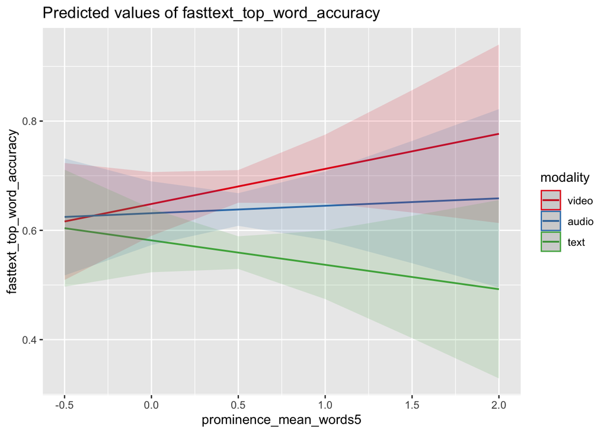

```r
plot_model(model, type='pred', terms=c('prominence_mean_words5', 'modality'))
```